# SKL_2

There is map available in skilearn to choosed ML model. https://scikit-learn.org/stable/tutorial/machine_learning_map/index.html

How to chose ML model in sklear(search)?

In sklearn, model is called estimator. ML applications has been divided ainto four broad categories. Classification Clustering Regression Dimensionality regression.

Every application has pre_built models.

How to choose these models? following things must be known to decide about choosing the model: what is to be predicted? E.g if number is to be predicted, it will be regression problem.

Predicting numbers is regression.

Whether labelled data is available or not?

Number of samples we have.

iF Ridge doesn't give high score we will move to Ensemble Regressor.

Ensemble Methods: Take many regressor model and give average of it.

Forestof randomzed tree: it is collection of if else statement.

Classification: Choosing either yes or no is classification. E.g either a person is ill or healthy?

If we have structured data, prefer ensemble method. If we have unstructured data, apply deep learning.

Note: For structured data prefer ensemble methods. For unstructured data prefer deep learning.

# Importing Data, Boston Hosusing

```python
import pandas as pd
from sklearn.datasets import load_boston
boston=load_boston()
boston
```

[output not shown]

[output cut: 8 more lines]

[output not shown]

```python
df_boston= pd.DataFrame(boston["data"], columns=boston["feature_names"])
df_boston["target"]= pd.Series(boston["target"])
df_boston.head()
```

|  | CRIM | ZN | INDUS | CHAS | NOX | RM | AGE | DIS | RAD | TAX | PTRATIO | B | LSTAT | target |
| --- | --- | --- | --- | --- | --- | --- | --- | --- | --- | --- | --- | --- | --- | --- |
| 0 | 0.00632 | 18.0 | 2.31 | 0.0 | 0.538 | 6.575 | 65.2 | 4.0900 | 1.0 | 296.0 | 15.3 | 396.90 | 4.98 | 24.0 |
| 1 | 0.02731 | 0.0 | 7.07 | 0.0 | 0.469 | 6.421 | 78.9 | 4.9671 | 2.0 | 242.0 | 17.8 | 396.90 | 9.14 | 21.6 |
| 2 | 0.02729 | 0.0 | 7.07 | 0.0 | 0.469 | 7.185 | 61.1 | 4.9671 | 2.0 | 242.0 | 17.8 | 392.83 | 4.03 | 34.7 |
| 3 | 0.03237 | 0.0 | 2.18 | 0.0 | 0.458 | 6.998 | 45.8 | 6.0622 | 3.0 | 222.0 | 18.7 | 394.63 | 2.94 | 33.4 |
| 4 | 0.06905 | 0.0 | 2.18 | 0.0 | 0.458 | 7.147 | 54.2 | 6.0622 | 3.0 | 222.0 | 18.7 | 396.90 | 5.33 | 36.2 |

```python
len(df_boston)
```

```
506
```

```python
from sklearn.linear_model import Ridge
import numpy as np
from sklearn.model_selection import train_test_split

#to prouce same results for following ML
np.random.seed(1)
#create data
x=df_boston.drop("target", axis=1)
y=df_boston["target"]
#split into test and train
x_train, x_test, y_train, y_test = train_test_split(x,y, test_size=0.2)
#instantiate ridge model
reg_model= Ridge()
reg_model.fit(x_train, y_train)
#check the score of model
reg_model.score(x_test, y_test)
```

```
0.7655800611077144
```

```python
#Changing model from regression libraries to improve result.
from sklearn.ensemble import RandomForestRegressor
import numpy as np
from sklearn.model_selection import train_test_split

#to prouce same results for following ML
np.random.seed(1)
#create data
x=df_boston.drop("target", axis=1)
y=df_boston["target"]
#split into test and train
x_train, x_test, y_train, y_test = train_test_split(x,y, test_size=0.2)
#instantiate ridge model
reg_model= RandomForestRegressor()
reg_model.fit(x_train, y_train)
#check the score of model
reg_model.score(x_test, y_test)
```

```
0.9124687687774722
```

```python
heart_data=pd.read_csv('heart_failure_clinical_records_dataset.csv')
heart_data
```

|  | age | anaemia | creatinine_phosphokinase | diabetes | ejection_fraction | high_blood_pressure | platelets | serum_creatinine | serum_sodium | sex | smoking | time | DEATH_EVENT |
| --- | --- | --- | --- | --- | --- | --- | --- | --- | --- | --- | --- | --- | --- |
| 0 | 75.0 | 0 | 582 | 0 | 20 | 1 | 265000.00 | 1.9 | 130 | 1 | 0 | 4 | 1 |
| 1 | 55.0 | 0 | 7861 | 0 | 38 | 0 | 263358.03 | 1.1 | 136 | 1 | 0 | 6 | 1 |
| 2 | 65.0 | 0 | 146 | 0 | 20 | 0 | 162000.00 | 1.3 | 129 | 1 | 1 | 7 | 1 |
| 3 | 50.0 | 1 | 111 | 0 | 20 | 0 | 210000.00 | 1.9 | 137 | 1 | 0 | 7 | 1 |
| 4 | 65.0 | 1 | 160 | 1 | 20 | 0 | 327000.00 | 2.7 | 116 | 0 | 0 | 8 | 1 |
| ... | ... | ... | ... | ... | ... | ... | ... | ... | ... | ... | ... | ... | ... |
| 294 | 62.0 | 0 | 61 | 1 | 38 | 1 | 155000.00 | 1.1 | 143 | 1 | 1 | 270 | 0 |
| 295 | 55.0 | 0 | 1820 | 0 | 38 | 0 | 270000.00 | 1.2 | 139 | 0 | 0 | 271 | 0 |
| 296 | 45.0 | 0 | 2060 | 1 | 60 | 0 | 742000.00 | 0.8 | 138 | 0 | 0 | 278 | 0 |
| 297 | 45.0 | 0 | 2413 | 0 | 38 | 0 | 140000.00 | 1.4 | 140 | 1 | 1 | 280 | 0 |
| 298 | 50.0 | 0 | 196 | 0 | 45 | 0 | 395000.00 | 1.6 | 136 | 1 | 1 | 285 | 0 |

299 rows × 13 columns

```python
len(heart_data)
```

```
299
```

```python
#Changing model from regression libraries to improve result.
from sklearn.svm import LinearSVC
import numpy as np
from sklearn.model_selection import train_test_split

#to prouce same results for following ML
#np.random.seed(1)
#create data
x=heart_data.drop("DEATH_EVENT", axis=1)
y=heart_data["DEATH_EVENT"]
#split into test and train
x_train, x_test, y_train, y_test = train_test_split(x,y, test_size=0.2)
#instantiate ridge model
svm_model= LinearSVC()
svm_model.fit(x_train, y_train)
#check the score of model
svm_model.score(x_test, y_test)
```

```
0.2833333333333333
```

```python
#Changing model from regression libraries to improve result.
from sklearn.ensemble import RandomForestClassifier
import numpy as np
from sklearn.model_selection import train_test_split

#to prouce same results for following ML
#np.random.seed(1)
#create data
x=heart_data.drop("DEATH_EVENT", axis=1)
y=heart_data["DEATH_EVENT"]
#split into test and train
x_train, x_test, y_train, y_test = train_test_split(x,y, test_size=0.2)
#instantiate ridge model
svm_model= RandomForestClassifier()
svm_model.fit(x_train, y_train)
#check the score of model
svm_model.score(x_test, y_test)
```

```
0.8666666666666667
```

# Making Prediction:

There are two ways of prediction: predict(). predict_proba().

Stages of execution of ML model: Stage 1: Training. Stage 2 Predicting.

When score is calculated, there must a predicted value. When score is run, it calls predicted values in the background.

For stage 2 there ust be actual value as well as predicted value. Now, scre compares actual and predicted and tells how much they resemble.

firstly, system is trained. When test data is given then firstly compiler predicts output of test data and then compare it with real output.

predict() method predicts individual value. Predict_proba gives probability of individual target value.

# Prediction on Classification Models

# Predict() Method:

```python
heart_dis = pd.read_csv('heart.csv')
heart_dis.head()
```

|  | age | sex | cp | trestbps | chol | fbs | restecg | thalach | exang | oldpeak | slope | ca | thal | target |
| --- | --- | --- | --- | --- | --- | --- | --- | --- | --- | --- | --- | --- | --- | --- |
| 0 | 63 | 1 | 3 | 145 | 233 | 1 | 0 | 150 | 0 | 2.3 | 0 | 0 | 1 | 1 |
| 1 | 37 | 1 | 2 | 130 | 250 | 0 | 1 | 187 | 0 | 3.5 | 0 | 0 | 2 | 1 |
| 2 | 41 | 0 | 1 | 130 | 204 | 0 | 0 | 172 | 0 | 1.4 | 2 | 0 | 2 | 1 |
| 3 | 56 | 1 | 1 | 120 | 236 | 0 | 1 | 178 | 0 | 0.8 | 2 | 0 | 2 | 1 |
| 4 | 57 | 0 | 0 | 120 | 354 | 0 | 1 | 163 | 1 | 0.6 | 2 | 0 | 2 | 1 |

```python
x1= heart_dis.drop('target', axis=1)
y1=heart_dis['target']
```

```python
#Choosing ML model.
from sklearn.ensemble import RandomForestClassifier
#splitting data into test and train
from sklearn.model_selection import train_test_split
x1_test, x1_train, y1_test, y1_train = train_test_split(x1,y1, test_size=0.2)
clf=RandomForestClassifier().fit(x1_train, y1_train)
```

```python
#evaluating mode
y1_predicted= clf.predict(x1_test)
y1_predicted # predicted output of y1_test data
```

```
array([0, 1, 1, 1, 0, 0, 1, 0, 1, 1, 0, 1, 0, 0, 0, 1, 1, 1, 0, 0, 0, 1,
       1, 1, 1, 1, 1, 1, 1, 1, 0, 0, 1, 0, 1, 0, 1, 0, 0, 0, 1, 1, 0, 1,
       1, 1, 1, 1, 0, 0, 1, 1, 0, 1, 1, 1, 1, 1, 1, 1, 1, 1, 0, 0, 0, 1,
       0, 0, 1, 1, 1, 1, 1, 1, 1, 1, 1, 1, 0, 1, 1, 1, 0, 1, 0, 1, 1, 0,
       0, 1, 1, 1, 1, 0, 0, 1, 1, 0, 1, 0, 1, 1, 1, 1, 0, 1, 1, 0, 1, 0,
       0, 1, 0, 0, 1, 1, 1, 1, 0, 0, 0, 1, 0, 1, 1, 1, 1, 1, 0, 1, 1, 1,
       1, 1, 0, 0, 0, 1, 1, 1, 0, 1, 1, 1, 0, 0, 1, 1, 1, 1, 1, 1, 1, 0,
       0, 0, 1, 1, 0, 0, 1, 0, 1, 0, 1, 1, 0, 1, 0, 0, 0, 0, 0, 0, 0, 1,
       1, 0, 0, 0, 1, 1, 1, 0, 1, 0, 1, 1, 0, 0, 1, 0, 1, 1, 1, 1, 1, 0,
       0, 1, 0, 1, 1, 1, 0, 0, 1, 1, 1, 0, 0, 0, 1, 1, 1, 0, 0, 0, 0, 1,
       1, 0, 0, 1, 1, 1, 0, 0, 0, 0, 1, 1, 1, 1, 1, 1, 0, 0, 0, 0, 1, 1],
      dtype=int64)
```

```python
np.array(y1_test) #real output of test data
```

```
array([0, 1, 1, 1, 0, 0, 1, 1, 1, 1, 0, 0, 0, 0, 0, 1, 1, 1, 0, 0, 1, 1,
       1, 1, 0, 1, 1, 1, 1, 1, 0, 0, 0, 0, 1, 0, 1, 0, 0, 0, 1, 1, 1, 1,
       1, 1, 1, 1, 0, 0, 1, 1, 0, 1, 1, 0, 1, 1, 1, 1, 1, 0, 0, 1, 0, 0,
       0, 0, 1, 0, 1, 1, 1, 1, 1, 0, 1, 0, 0, 1, 1, 0, 0, 1, 0, 1, 1, 1,
       1, 1, 1, 1, 0, 0, 1, 1, 0, 0, 0, 0, 1, 1, 1, 1, 0, 1, 1, 0, 1, 0,
       0, 1, 0, 0, 1, 1, 1, 1, 0, 0, 0, 1, 0, 0, 1, 0, 1, 1, 0, 0, 1, 1,
       0, 0, 0, 0, 0, 1, 1, 0, 0, 1, 0, 1, 0, 0, 0, 1, 1, 1, 1, 0, 0, 0,
       0, 0, 1, 1, 0, 0, 1, 0, 0, 0, 0, 1, 1, 1, 0, 0, 0, 0, 0, 0, 0, 0,
       1, 0, 1, 1, 1, 1, 1, 0, 1, 0, 1, 1, 0, 0, 1, 0, 1, 1, 1, 1, 1, 0,
       1, 1, 0, 1, 0, 1, 1, 0, 1, 1, 1, 0, 0, 0, 1, 1, 1, 0, 0, 0, 0, 1,
       0, 0, 0, 1, 1, 1, 1, 1, 0, 1, 1, 1, 0, 1, 1, 1, 0, 0, 0, 0, 1, 0],
      dtype=int64)
```

```python
np.mean(y1_predicted == y1_test) #method 1 to find score
```

```
0.8140495867768595
```

```python
clf.score(x1_test, y1_test) # METHOD 2 to find score.
```

```
0.8140495867768595
```

Here actually score() method is called upon model RandomforestClassifier which is trained by train data an now test data is given to find score or to find how much y1_test is as similar as predicted by machine.

# Preddict_proba()

Predict_proba gives probability of individual target value

```python
clf.predict(x1_test)[:5]
```

```
array([0, 1, 1, 1, 0], dtype=int64)
```

```python
clf.predict_proba(x1_test)[:5]
```

```
array([[0.78, 0.22],
       [0.2 , 0.8 ],
       [0.39, 0.61],
       [0.09, 0.91],
       [0.93, 0.07]])
```

# Prediction on Regression Models:

```python
#Changing model from regression libraries to improve result.
from sklearn.ensemble import RandomForestRegressor
import numpy as np
from sklearn.model_selection import train_test_split

#to prouce same results for following ML
np.random.seed(1)

#create data
x=df_boston.drop("target", axis=1)
y=df_boston["target"]

#split into test and train
x_train, x_test, y_train, y_test = train_test_split(x,y, test_size=0.2)

#instantiate ridge model
reg_model= RandomForestRegressor()
reg_model.fit(x_train, y_train)

#check the score of model
predict_y_test = reg_model.predict(x_test)
```

```python
predict_y_test[:5] # predicted value.
```

```
array([29.926, 27.022, 20.343, 20.593, 19.64 ])
```

```python
np.array(y_test)[:5] # real value of y_test, ground reality.
```

```
array([28.2, 23.9, 16.6, 22. , 20.8])
```

```python
#compare prediction with real values of y_test, ground reality
# or finding deviation of predicted value from the real ones i.e y_test.
from sklearn.metrics import mean_absolute_error
mean_absolute_error(y_test, predict_y_test)
```

```
2.2971568627451
```

# Evaluating ML Models:

```
Three ways:
Estimator "Score Method.
The Scoring Parameter.
Problem_Specific metric method.
```

https://scikit-learn.org/stable/modules/model_evaluation.html

```python
#Changing model from regression libraries to improve result.
from sklearn.ensemble import RandomForestClassifier
import numpy as np
from sklearn.model_selection import train_test_split

#to prouce same results for following ML
#np.random.seed(1)
#create data
x=heart_data.drop("DEATH_EVENT", axis=1)
y=heart_data["DEATH_EVENT"]
#split into test and train
x_train, x_test, y_train, y_test = train_test_split(x,y, test_size=0.2)
#instantiate ridge model
svm_model= RandomForestClassifier()
svm_model.fit(x_train, y_train)
#check the score of model
svm_model.score(x_test, y_test)
```

```
0.8333333333333334
```

check help regarding score methods.

```
"Return the mean accuracy on the given test data and labels."

scrore is using mean accuracy metrics.
```

```python
#Changing model from regression libraries to improve result.
from sklearn.ensemble import RandomForestRegressor
import numpy as np
from sklearn.model_selection import train_test_split

#to prouce same results for following ML
np.random.seed(1)
#create data
x=df_boston.drop("target", axis=1)
y=df_boston["target"]
#split into test and train
x_train, x_test, y_train, y_test = train_test_split(x,y, test_size=0.2)
#instantiate ridge model
reg_model= RandomForestRegressor()
reg_model.fit(x_train, y_train)
#check the score of model
reg_model.score(x_test, y_test)
```

```
0.9124687687774722
```

check help regarding score methods.

```
Return the coefficient of determination R^2 of the prediction.

scrore is using R^2 accuracy metrics.
```

# Cross Validation:

CV splits data into numbers given to CV If CV=5, it will split data into 5 parts. Moreover, if test_size=0.2, CV will take 20 percent of data from every split.

Cross validation gives u the ability to use different scoring matrices.

CV: cross validation splitting strategy.

```python
from sklearn.ensemble import RandomForestClassifier
from sklearn.model_selection import train_test_split

#to prouce same results for following ML
#np.random.seed(1)
#create data
x=heart_data.drop("DEATH_EVENT", axis=1)
y=heart_data["DEATH_EVENT"]

x_train, x_test , y_train, y_test= train_test_split(x,y, test_size=0.2)
heart_model= RandomForestClassifier().fit(x_train,y_train)

heart_model.score(x_test, y_test)
```

```
0.8333333333333334
```

```python
from sklearn.model_selection import cross_val_score
cross_val_score(heart_model, x, y, cv=5)
```

```
array([0.45      , 0.85      , 0.83333333, 0.71666667, 0.6779661 ])
```

Moreover, CV uses defualt scoring method i.e for mean accuracy for default and R^2 for regression, but it also gives opportunity to change it,

```python
cross_val_score(heart_model, x, y, cv=5, scoring=None)
```

```
array([0.45      , 0.81666667, 0.85      , 0.71666667, 0.6779661 ])
```

```python
heart_model.score(x_test, y_test), np.mean(cross_val_score(heart_model, x, y, cv=5,scoring=None))# cross validation accracy.
```

```
(0.8333333333333334, 0.6889830508474576)
```

# Classification Model Evaluation:

it can be evaluated using using four metrics:

```
    1 Accuracy.
    2 Area Under the Curve ROC.
    3 Confusion Matrix
    4 Classification Report
```

```python
print(f"heart disease cross validation accuracy is { np.mean(cross_val_score(heart_model, x, y, cv=5,scoring=None))*100:2f}")
```

```
heart disease cross validation accuracy is 68.559322
```

# Area Under the Curve (AUC) or Reciever Operating Characteristic Curve (ROC)

```python
from sklearn.ensemble import RandomForestClassifier
from sklearn.metrics import roc_curve

x_train, x_test , y_train, y_test= train_test_split(x,y, test_size=0.2)
clf=RandomForestClassifier().fit(x_train, y_train)

clf.fit(x_train,y_train)
y_prob = clf.predict_proba(x_test)
```

predict_proba gives multiple probabilities and mean of all these is taken. This is one dimensional vector.

while score gives only single value which is zero dimesional.

to increase reliability we are taking two dimensional vectors of fpr and tpr. In order to calculate this, we use area under the curve.

```python
y_prob[:5]
```

```
array([[0.79, 0.21],
       [0.84, 0.16],
       [0.54, 0.46],
       [0.64, 0.36],
       [0.37, 0.63]])
```

True positive: Model's prediction of 1 similar to real value 1.

True negative: Model's prediction of 0 similar to real value 0.

False negative: Model's prediction of 0 does not similar to real value i.e 1.

(positive: Model's 1, Negative: Model's 0)

Cases:

Case 1: True Positive : Truth= 1, Model=1

Case 2: False Positive : Truth= 0, Model=1

Case 3: True Negative : Truth= 0, Model=0

Case 4: False Negative : Truth= 1, Model=0

```python
y_prob_positive= y_prob[:,1] # finding probability of y only.
```

```python
y_prob_positive
```

```
array([0.21, 0.16, 0.46, 0.36, 0.63, 0.03, 0.81, 0.21, 0.54, 0.78, 0.17,
       0.1 , 0.13, 0.11, 0.05, 0.48, 0.03, 0.11, 0.06, 0.69, 0.07, 0.03,
       0.15, 0.02, 0.36, 0.53, 0.08, 0.83, 0.74, 0.03, 0.31, 0.28, 0.07,
       0.  , 0.74, 0.76, 0.09, 0.12, 0.42, 0.13, 0.24, 0.06, 0.21, 0.56,
       0.84, 0.07, 0.8 , 0.49, 0.74, 0.79, 0.02, 0.23, 0.13, 0.06, 0.21,
       0.36, 0.1 , 0.87, 0.21, 0.11])
```

```python
fpr, tpr, threshold= roc_curve(y_test, y_prob_positive)
```

```python
fpr #false_positive_rate
```

```
array([0.   , 0.   , 0.   , 0.   , 0.   , 0.075, 0.15 , 0.225, 0.225,
       0.325, 0.4  , 0.45 , 0.475, 0.55 , 0.6  , 0.65 , 0.8  , 0.825,
       0.925, 0.975, 1.   ])
```

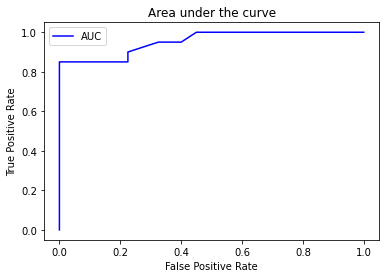

```python
#Creatinf funtion for plotting
import matplotlib.pyplot as plt
def plot_roc(fpr,tpr):

    #plot roc curve
    plt.plot(fpr,tpr, color="blue", label="AUC")

    #Customize the plot
    plt.title("Area under the curve")
    plt.xlabel("False Positive Rate")
    plt.ylabel("True Positive Rate")
    plt.legend()
    plt.show()

plot_roc(fpr,tpr)
```

```python
#value of AUC
from sklearn.metrics import roc_auc_score
roc_auc_score(y_test, y_prob_positive)
```

```
0.95375
```

# Confusion Matrics:

```
It finds out Where model is confused or has lost his minds.
model is giving wrong prediction in case 2 and case 4.
```

```python
from sklearn.metrics import confusion_matrix
y_predicted = heart_model.predict(x_test)
confusion_matrix(y_test, y_predicted)
```

```
array([[39,  1],
       [ 3, 17]], dtype=int64)
```

Here, at position of 3 and 1 model is confused.

```python
#Installing seaborn Heatmap
import sys
!conda install -- prefix {sys.prefix} seaborn
```

```
Solving environment: ...working... failed with initial frozen solve. Retrying with flexible solve.
Solving environment: ...working... failed with initial frozen solve. Retrying with flexible solve.
```

[output not shown]

```python
import seaborn as sns

conf_mat= confusion_matrix(y_test, y_predicted)

def plot_conf_matrix(conf_mat):
    """
    This function plots confuion matrix
    """
    fig, ax=plt.subplots(figsize=(3,3))
    ax=sns.heatmap(conf_mat, annot=True, cbar=False)

    plt.xlabel(" Truth")
    plt.ylabel("predicted")
```

https://seaborn.pydata.org/generated/seaborn.heatmap.html

use this link to read documentation of seaborn map.

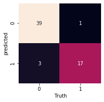

```python
plot_conf_matrix(conf_mat)
```

Here balck region is showing where matrix is getting confused.

# Classification Report:

```
1 Class imbalance.
2 Recall.
3 Precision.
4 F1 Score
```

class imbalance is actually imbalance between data and required data. Recall means to include data to find relevent things in data. Precision means to include relevent data. Recall and precision are inversaly proportional.

There must be balance between recall and precision which s called F1 Score :

1 Recall= TP/(TP+FN) 2 Precision =TP/(TP+FP) 3 cobination of precision and recall.

```python
from sklearn.metrics import classification_report
print(classification_report(y_test, y_predicted))
```

```
              precision    recall  f1-score   support

           0       0.93      0.97      0.95        40
           1       0.94      0.85      0.89        20

    accuracy                           0.93        60
   macro avg       0.94      0.91      0.92        60
weighted avg       0.93      0.93      0.93        60
```

https://scikit-learn.org/stable/modules/model_evaluation.html

# Regression Model Evaluation Metrics:

1 R^2: Compares your model with the mean of your target.

2 Mean Absolute Error (MAE)

3 Mean Squared Error (MSE)

https://scikit-learn.org/stable/modules/model_evaluation.html

# R^2:

In regression model value of R^2 model has is to be maximized.

```python
#Changing model from regression libraries to improve result.
from sklearn.ensemble import RandomForestRegressor
import numpy as np
from sklearn.model_selection import train_test_split

#to prouce same results for following ML
np.random.seed(1)

#create data
x=df_boston.drop("target", axis=1)
y=df_boston["target"]

#split into test and train
x_train, x_test, y_train, y_test = train_test_split(x,y, test_size=0.2)

#instantiate ridge model
reg_model= RandomForestRegressor()
reg_model.fit(x_train, y_train)

reg_model.score(x_test,y_test) # Here regression metrics is used to find score. You can find if shift+tab is used.
```

```
0.9124687687774722
```

# Mean Absolute Error:

It is the average of absolute(plus or complete) difference between predicted and actual. Rule of Thumb: Have to minimize this value.

Moreover, MAE take differences, add them up, turn them positive and take mean of them.

```python
from sklearn.metrics import mean_absolute_error

y_predicted = reg_model.predict(x_test,)
MAE= mean_absolute_error(y_test, y_predicted)

MAE
```

```
2.2971568627451
```

```python
df = pd.DataFrame(data={"actual_values":y_test, "predicted_values": y_predicted}  )
df["differences"]= df["actual_values"] - df["predicted_values"]
df
```

|  | actual_values | predicted_values | differences |
| --- | --- | --- | --- |
| 307 | 28.2 | 29.926 | -1.726 |
| 343 | 23.9 | 27.022 | -3.122 |
| 47 | 16.6 | 20.343 | -3.743 |
| 67 | 22.0 | 20.593 | 1.407 |
| 362 | 20.8 | 19.640 | 1.160 |
| ... | ... | ... | ... |
| 92 | 22.9 | 23.644 | -0.744 |
| 224 | 44.8 | 42.159 | 2.641 |
| 110 | 21.7 | 20.336 | 1.364 |
| 426 | 10.2 | 15.765 | -5.565 |
| 443 | 15.4 | 15.709 | -0.309 |

102 rows × 3 columns

collectively differences is 2.3.

# Mean Squared Error, MSE:

Takes difference, takes square, add them up and takes average. It will always be far higher than MAV

```python
from sklearn.metrics import mean_squared_error

y_pred= reg_model.predict(x_test)
mse= mean_squared_error(y_test, y_pred)
mse
```

```
8.650483078431385
```

```python
#taking MSE manually:
mse_manual= np.square(df["differences"]).mean()
mse_manual
```

```
8.650483078431384
```

MSE just amplify error by squaring it,

```python
from sklearn.model_selection import cross_val_score
from sklearn.ensemble import RandomForestClassifier
from sklearn.model_selection import train_test_split

#to prouce same results for following ML
#np.random.seed(1)
#create data
x=heart_data.drop("DEATH_EVENT", axis=1)
y=heart_data["DEATH_EVENT"]

x_train, x_test , y_train, y_test= train_test_split(x,y, test_size=0.2)
heart_model= RandomForestClassifier().fit(x_train,y_train)

heart_model.score(x_test, y_test)

cross_acc= cross_val_score(heart_model, x, y, cv=5, scoring=None)
cross_acc
```

```
array([0.45      , 0.85      , 0.83333333, 0.71666667, 0.6779661 ])
```

Using different parameters of scoring: use following link to know more about these parameters: https://scikit-learn.org/stable/modules/model_evaluation.html

```python
cross_acc=cross_val_score(heart_model, x, y, cv=5, scoring=None)
cross_acc.mean()
```

```
0.7022598870056498
```

```python
cross_acc=cross_val_score(heart_model, x, y, cv=5, scoring="accuracy")
cross_acc.mean()
```

```
0.6889830508474576
```

```python
cross_acc=cross_val_score(heart_model, x, y, cv=5, scoring="precision")
cross_acc.mean()
```

```
0.4600956937799043
```

```python
cross_acc=cross_val_score(heart_model, x, y, cv=5, scoring="f1")
cross_acc.mean()
```

```
0.489365721997301
```

# Scoring Parameters for Regression:

```python
#Changing model from regression libraries to improve result.
from sklearn.ensemble import RandomForestRegressor
import numpy as np
from sklearn.model_selection import train_test_split
from sklearn.model_selection import cross_val_score

#to prouce same results for following ML
np.random.seed(7)

#create data
x=df_boston.drop("target", axis=1)
y=df_boston["target"]

#split into test and train
x_train, x_test, y_train, y_test = train_test_split(x,y, test_size=0.2)

#instantiate ridge model
cl_f= RandomForestRegressor()
cl_f.fit(x_train, y_train)

cl_f.score(x_test,y_test) # Here regression metrics is used to find score. You can find if shift+tab is used.
```

```
0.8092443411593175
```

```python
cross_acc= cross_val_score(cl_f, x,y, cv=5, scoring=None)
cross_acc.mean()
```

```
0.6314044391665344
```

```python
cross_acc= cross_val_score(cl_f, x,y,cv=5, scoring="r2")
cross_acc.mean()
```

```
0.618621010722269
```

```python
cross_acc= cross_val_score(cl_f, x,y,cv=5, scoring="neg_mean_absolute_error")
cross_acc.mean()
```

```
-2.968636594835953
```

```python
cross_acc= cross_val_score(cl_f, x,y,cv=5, scoring="neg_mean_squared_error")
cross_acc.mean()
```

```
-21.8976219086585
```

# Metric Function for Classifiction:

```python
from sklearn.ensemble import RandomForestClassifier
from sklearn.model_selection import train_test_split
from sklearn.metrics import accuracy_score, recall_score, f1_score, precision_score

#to prouce same results for following ML
#np.random.seed(1)
#create data
x=heart_data.drop("DEATH_EVENT", axis=1)
y=heart_data["DEATH_EVENT"]

x_train, x_test , y_train, y_test= train_test_split(x,y, test_size=0.2)
heart_model= RandomForestClassifier().fit(x_train,y_train)

heart_model.score(x_test, y_test)
#predicting
y_predict = heart_model.predict(x_test)

print(f"accuracy score is {accuracy_score(y_test, y_predict)}")
print(f"recall score is {recall_score(y_test, y_predict)}")
print(f"f1 score is {f1_score(y_test, y_predict)}")
print(f"precision score is {precision_score(y_test, y_predict)}")
```

```
accuracy score is 0.85
recall score is 0.6818181818181818
f1 score is 0.7692307692307693
precision score is 0.8823529411764706
```

# Evaluation Using Function Regression:

```python
#Changing model from regression libraries to improve result.
from sklearn.metrics import r2_score, mean_absolute_error, mean_squared_error
from sklearn.ensemble import RandomForestRegressor
import numpy as np
from sklearn.model_selection import train_test_split

#to prouce same results for following ML
np.random.seed(7)
#create data
x=df_boston.drop("target", axis=1)
y=df_boston["target"]
#split into test and train
x_train, x_test, y_train, y_test = train_test_split(x,y, test_size=0.2)
#instantiate ridge model
reg_model= RandomForestRegressor()
reg_model.fit(x_train, y_train)
#check the score of model
y_pred= reg_model.predict(x_test)
```

```python
print(f"r2_score value     : {r2_score(y_pred, y_test)}")
print(f"mean_absolute_error: {mean_absolute_error(y_pred, y_test)}")
print(f"mean_squared_error : {mean_squared_error(y_pred, y_test)}")
```

```
r2_score value     : 0.7875612536529618
mean_absolute_error: 2.3153627450980383
mean_squared_error : 15.414251382352935
```

# Improve Models: 3 Methods:

```
    1 Improving quality and quantity of data.
    2 Choosing model from less to more complex/robust e.g from Ridge to RnadomForestRegressor.
    3 Improving Model using Hyperparameters.
```

# Hyperparameters:

Parameters used for fine tuning is called. Every model has particular set of parameters.

It can be changed by three ways:

# 1 Manually.

# 2 Randomly with RandomSearchCV.

# 3 Exaustively GridSearchCV.

To apply hyperparameters data is splitted into another third part i.e called Validation Part, and upon VP hyperparameters are applied.

Task 1:

Split data into test, train and validation.

Task 2:

Apply parameters on it.

https://scikit-learn.org/stable/modules/generated/sklearn.ensemble.RandomForestClassifier.html

```python
from sklearn.ensemble import RandomForestClassifier
clf=RandomForestClassifier()
clf.get_params() # giving all the parameters.
```

```
{'bootstrap': True,
 'ccp_alpha': 0.0,
 'class_weight': None,
 'criterion': 'gini',
 'max_depth': None,
 'max_features': 'auto',
 'max_leaf_nodes': None,
 'max_samples': None,
 'min_impurity_decrease': 0.0,
 'min_impurity_split': None,
 'min_samples_leaf': 1,
 'min_samples_split': 2,
 'min_weight_fraction_leaf': 0.0,
 'n_estimators': 100,
 'n_jobs': None,
 'oob_score': False,
 'random_state': None,
 'verbose': 0,
 'warm_start': False}
```

```python
from sklearn.ensemble import RandomForestRegressor
clf1=RandomForestRegressor()
clf1.get_params()
```

```
{'bootstrap': True,
 'ccp_alpha': 0.0,
 'criterion': 'mse',
 'max_depth': None,
 'max_features': 'auto',
 'max_leaf_nodes': None,
 'max_samples': None,
 'min_impurity_decrease': 0.0,
 'min_impurity_split': None,
 'min_samples_leaf': 1,
 'min_samples_split': 2,
 'min_weight_fraction_leaf': 0.0,
 'n_estimators': 100,
 'n_jobs': None,
 'oob_score': False,
 'random_state': None,
 'verbose': 0,
 'warm_start': False}
```

```python
#prediction evaluation function:
from sklearn.metrics import accuracy_score, recall_score, f1_score, precision_score

def evaluate_hyp_metrics(y_true, y_predicted):
    accuracy=accuracy_score(y_true, y_predicted)
    precision=precision_score(y_true, y_predicted)
    recall=recall_score(y_true, y_predicted)
    f1=f1_score(y_true, y_predicted)

    metrics_dict={"Accuracy": accuracy,
                 "precision": precision,
                 "recall": recall,
                 "f1":f1}

    print(f"Accuracy: {round(accuracy,2)}") # round(): to round up figure.
    print(f"precision:{ round(precision,2)}")
    print(f"recall: {round(recall,2)}")
    print(f"f1: {round(f1,2)}")
    return metrics_dict  #generally no need of ot
```

```python
#Shufling whole data
mix_heart_data= heart_data.sample(frac=1)
#Splitting data into three parts i.e test, train and validation.
x=mix_heart_data.drop("DEATH_EVENT", axis=1)
y=mix_heart_data["DEATH_EVENT"]

train_split= round(0.7*len(mix_heart_data))
valid_split= round(train_split + 0.15*len(mix_heart_data))
#test_split= round(0.15*len(mix_heart_data))

x_train, y_train=x[:train_split], y[:train_split]
x_valid, y_valid=x[train_split:valid_split], y[train_split:valid_split]
x_test, y_test=x[valid_split:], y[valid_split:]
```

```python
clf=RandomForestClassifier()
clf.fit(x_train,y_train)
#baseline prediction
y1_predicted=clf.predict(x_valid)

first_result=evaluate_hyp_metrics(y_valid, y1_predicted)
first_result
```

```
Accuracy: 0.89
precision:0.89
recall: 0.67
f1: 0.76
```

```
{'Accuracy': 0.8888888888888888,
 'precision': 0.8888888888888888,
 'recall': 0.6666666666666666,
 'f1': 0.761904761904762}
```

```python
clf2=RandomForestClassifier(n_estimators=10)
clf2.fit(x_train,y_train)
#baseline prediction
y2_predicted=clf2.predict(x_valid)

second_result=evaluate_hyp_metrics(y_valid,y2_predicted)
second_result
```

```
Accuracy: 0.89
precision:0.89
recall: 0.67
f1: 0.76
```

```
{'Accuracy': 0.8888888888888888,
 'precision': 0.8888888888888888,
 'recall': 0.6666666666666666,
 'f1': 0.761904761904762}
```

```python
clf3=RandomForestClassifier(n_estimators=10, max_depth=10)
clf3.fit(x_train,y_train)
#baseline prediction
y3_predicted=clf3.predict(x_valid)

third_result=evaluate_hyp_metrics(y_valid,y3_predicted)
third_result
```

```
Accuracy: 0.84
precision:0.86
recall: 0.5
f1: 0.63
```

```
{'Accuracy': 0.8444444444444444,
 'precision': 0.8571428571428571,
 'recall': 0.5,
 'f1': 0.631578947368421}
```

```python
len(mix_heart_data)
```

```
299
```

```python
len(x_train), len(x_valid), len(x_test)
```

```
(209, 45, 45)
```

```python
#Showing parameters.
clf4=RandomForestClassifier()
clf4.get_params()
```

```
{'bootstrap': True,
 'ccp_alpha': 0.0,
 'class_weight': None,
 'criterion': 'gini',
 'max_depth': None,
 'max_features': 'auto',
 'max_leaf_nodes': None,
 'max_samples': None,
 'min_impurity_decrease': 0.0,
 'min_impurity_split': None,
 'min_samples_leaf': 1,
 'min_samples_split': 2,
 'min_weight_fraction_leaf': 0.0,
 'n_estimators': 100,
 'n_jobs': None,
 'oob_score': False,
 'random_state': None,
 'verbose': 0,
 'warm_start': False}
```

Now, it is very difficult to put every parameter manually and find the results. Therefore, we need to find some method in which every parameter is applied by it self and we retrieve value. That method is RSCV.

# Randomized Search Cross Validation (RSCV):

```
Tuning hyperparameters automatically.
```

n_estimators:[10,100,200,500,1000]

max_depth:[None,5,10,20,30]

min_samples_split[2,4,6]

min_samples_leaf[1,2,4]

max_features["auto", "sqrt"]

n_jobs

```python
hparams= {"n_estimators":[10,100,200,500,1000],
"max_depth":[None,5,10,20,30],
"min_samples_split":[2,4,6],
"min_samples_leaf":[1,2,4],
"max_features":["auto", "sqrt"]}

x=mix_heart_data.drop("DEATH_EVENT", axis=1)
y=mix_heart_data["DEATH_EVENT"]

x_train, x_test , y_train, y_test= train_test_split(x,y, test_size=0.2)

clf=RandomForestClassifier(n_jobs=1) #n_jobs will make processor to work on full capacity.
                                      #It will make program to execute early.
```

```python
from sklearn.model_selection import RandomizedSearchCV
rscv_clf=RandomizedSearchCV(estimator=clf, param_distributions=hparams, n_iter=10, cv=5, verbose=2)#verbose:to show o?p
rscv_clf.fit(x_train, y_train)
```

```
Fitting 5 folds for each of 10 candidates, totalling 50 fits
[CV] n_estimators=500, min_samples_split=6, min_samples_leaf=4, max_features=auto, max_depth=20
```

```
[Parallel(n_jobs=1)]: Using backend SequentialBackend with 1 concurrent workers.
```

```
[CV]  n_estimators=500, min_samples_split=6, min_samples_leaf=4, max_features=auto, max_depth=20, total=   1.4s
[CV] n_estimators=500, min_samples_split=6, min_samples_leaf=4, max_features=auto, max_depth=20
```

```
[Parallel(n_jobs=1)]: Done   1 out of   1 | elapsed:    1.3s remaining:    0.0s
```

[output not shown]

[output cut: 42 more lines]

[output not shown]

```
[Parallel(n_jobs=1)]: Done  50 out of  50 | elapsed:   38.7s finished
```

```
RandomizedSearchCV(cv=5, estimator=RandomForestClassifier(n_jobs=1),
                   param_distributions={'max_depth': [None, 5, 10, 20, 30],
                                        'max_features': ['auto', 'sqrt'],
                                        'min_samples_leaf': [1, 2, 4],
                                        'min_samples_split': [2, 4, 6],
                                        'n_estimators': [10, 100, 200, 500,
                                                         1000]},
                   verbose=2)
```

# Here RSCV will take hparams and applied it on estimator.

# n_iter: set of combination of values of parameters.

# total 10 combination, as 5 layers and 10 combinations for every layer.

```python
rscv_clf.best_params_
```

```
{'n_estimators': 100,
 'min_samples_split': 6,
 'min_samples_leaf': 1,
 'max_features': 'sqrt',
 'max_depth': 5}
```

```python
rscv_clf_predict= rscv_clf.predict(x_test)
fourth_result= evaluate_hyp_metrics(y_test, rscv_clf_predict) # evaluate_hyp_metrics is prediction evaluation function:
```

```
Accuracy: 0.78
precision:0.68
recall: 0.65
f1: 0.67
```

[output not shown]

Total combinations were 5 *5* 3 *3* 2 = 450 but we check only 10 n_iter=10 out of these. Can we check all of these combinationa? yes, by Grid Search Cross Validation

# grid Search Cross Validation:

Tuning the Hyper parameter using Grid Search Cross Validation(GSCV).

As a RSCV has given us most suitable values for every parameter. So, instead of taking all of the values given by we take only thos values which are close to values given by RSCV. if we take all of these then it would become 450*5.

```python
from sklearn.model_selection import GridSearchCV


hparams= {"n_estimators":[100,200,500,],
"max_depth":[None,5,10],
"min_samples_split":[2,4],
"min_samples_leaf":[2,4],
"max_features":["auto", "sqrt"]}

gscv_clf=GridSearchCV(estimator=clf, param_grid=hparams, cv=5, verbose=2)
gscv_clf.fit(x_train, y_train)
```

```
Fitting 5 folds for each of 72 candidates, totalling 360 fits
[CV] max_depth=None, max_features=auto, min_samples_leaf=2, min_samples_split=2, n_estimators=100
```

```
[Parallel(n_jobs=1)]: Using backend SequentialBackend with 1 concurrent workers.
```

```
[CV]  max_depth=None, max_features=auto, min_samples_leaf=2, min_samples_split=2, n_estimators=100, total=   0.3s
[CV] max_depth=None, max_features=auto, min_samples_leaf=2, min_samples_split=2, n_estimators=100
```

```
[Parallel(n_jobs=1)]: Done   1 out of   1 | elapsed:    0.2s remaining:    0.0s
```

[output not shown]

[output cut: 662 more lines]

[output not shown]

```
[Parallel(n_jobs=1)]: Done 360 out of 360 | elapsed:  4.0min finished
```

```
GridSearchCV(cv=5, estimator=RandomForestClassifier(n_jobs=1),
             param_grid={'max_depth': [None, 5, 10],
                         'max_features': ['auto', 'sqrt'],
                         'min_samples_leaf': [2, 4],
                         'min_samples_split': [2, 4],
                         'n_estimators': [100, 200, 500]},
             verbose=2)
```

```python
gscv_clf.best_params_
```

```
{'max_depth': None,
 'max_features': 'auto',
 'min_samples_leaf': 2,
 'min_samples_split': 2,
 'n_estimators': 100}
```

Result of RSCV, GSCV suggested that n_estimaor=100 would be the best.

'min_samples_split': 2,

'max_features': 'auto',

'max_depth': None}

```python
gscv_clf_predict= gscv_clf.predict(x_test)
fifth_result= evaluate_hyp_metrics(y_test, gscv_clf_predict) # evaluate_hyp_metrics is prediction evaluation function:
fifth_result
```

```
Accuracy: 0.78
precision:0.68
recall: 0.65
f1: 0.67
```

```
{'Accuracy': 0.7833333333333333,
 'precision': 0.6842105263157895,
 'recall': 0.65,
 'f1': 0.6666666666666667}
```

y1

rsvc

gsvc

1sr r

2 r

3 r

rsvc

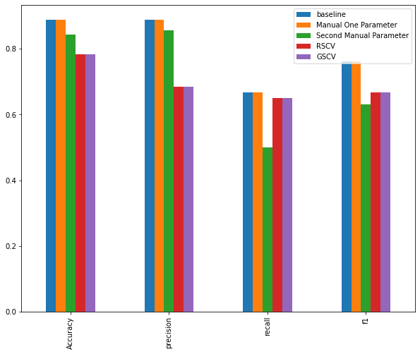

```python
comparison= pd.DataFrame({"baseline":first_result,
            "Manual One Parameter":second_result,
            "Second Manual Parameter": third_result,
            "RSCV":fourth_result,
            "GSCV":fifth_result})
comparison.plot.bar(figsize=(10,8))
```

# Saving Model:

```python
import pickle
pickle.dump(gscv_clf,open("gscv_clf_RFM.pkl","wb"))
```

```python
pickled_model=pickle.load(open("gscv_clf_RFM.pkl","rb"))
```

```python
predicted_pickled=pickled_model.predict(x_test)
evaluate_hyp_metrics(y_test, predicted_pickled)
```

```
Accuracy: 0.78
precision:0.68
recall: 0.65
f1: 0.67
```

```
{'Accuracy': 0.7833333333333333,
 'precision': 0.6842105263157895,
 'recall': 0.65,
 'f1': 0.6666666666666667}
```

Another way to save model:

```python
from joblib import dump,load
#Saving the model.
dump(gscv_clf, filename="joblib_gscv_model.joblib")
```

```
['joblib_gscv_model.joblib']
```

```python
joblib_model= load(filename="joblib_gscv_model.joblib")
```

```python
y_joblib_predicted = joblib_model.predict(x_test)
evaluate_hyp_metrics(y_test, y_joblib_predicted)
```

```
Accuracy: 0.78
precision:0.68
recall: 0.65
f1: 0.67
```

```
{'Accuracy': 0.7833333333333333,
 'precision': 0.6842105263157895,
 'recall': 0.65,
 'f1': 0.6666666666666667}
```